# Tugas-Pertemuan-2

Abie G1401231069

2025-08-31

```r
library("forecast")
library("graphics")
library("TTR")
library("TSA")
library("rio")
library("ggplot2")
```

# Data

```r
dataaqi<-read.csv("C:\\Users\\Abie\\OneDrive\\Documents\\5\\mpdw\\dataudarajkt.csv")
dataaqi<-dataaqi[1:125,c(1,4)] # Periode 1 sampai 125
dataaqi$periode<-seq(125)
dataaqi<-dataaqi[,c("periode","tanggal","pm10")]
head(dataaqi)
```

```
##   periode    tanggal pm10
## 1       1 2023-10-18   64
## 2       2 2023-10-19   65
## 3       3 2023-10-20   62
## 4       4 2023-10-21   63
## 5       5 2023-10-22   60
## 6       6 2023-10-23   62
```

```r
dataaqi.ts<-ts(dataaqi$pm10)
summary(dataaqi.ts)
```

```
##    Min. 1st Qu.  Median    Mean 3rd Qu.    Max.
##   19.00   38.00   51.00   47.75   58.00   70.00
```

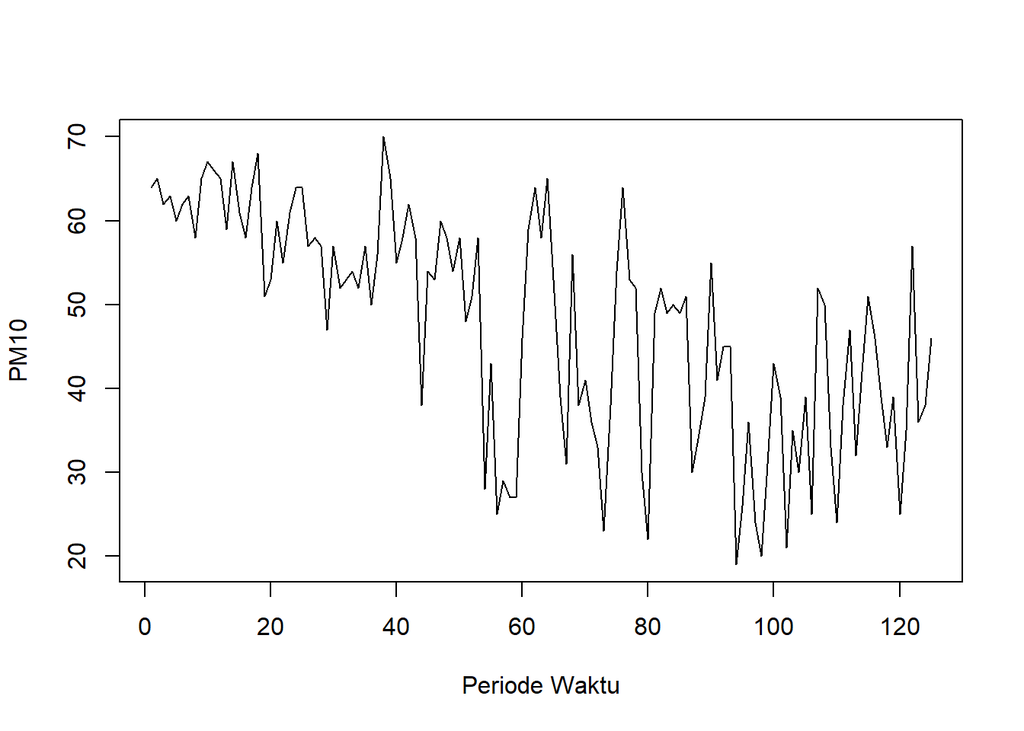

```r
ts.plot(dataaqi.ts, xlab="Periode Waktu", ylab="PM10")
```

Dari plot di atas, dapat dilihat bahwa data pm10 memiliki pola kecenderungan turun di periode-periode awal, kemudian sedikit stabil di periode-periode setelahnya.

## Data Train dan Test

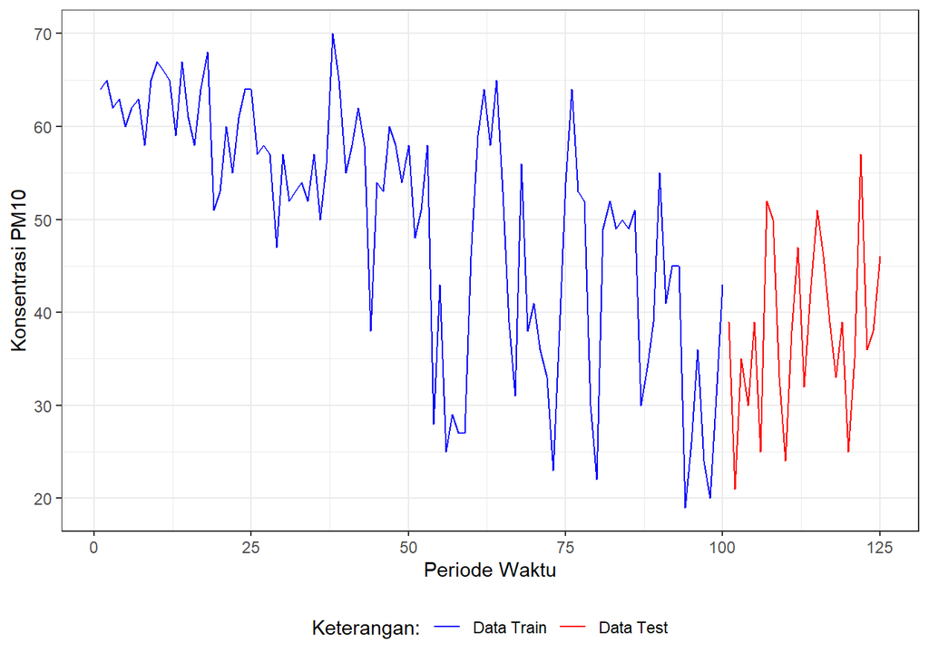

```r
n_train <- floor(0.8 * length(dataaqi.ts))
n_test <- length(dataaqi.ts) - n_train

# Masih bentuk data frame
training.ts <- dataaqi[1:n_train,]
testing.ts <- dataaqi[(n_train + 1):length(dataaqi.ts),]

# Bentuk data time series
train.ts <- ts(training.ts$pm10)
test.ts <- ts(testing.ts$pm10)

ggplot() +
  geom_line(data = training.ts, aes(x = periode, y = pm10, col = "Data Train")) +
  geom_line(data = testing.ts, aes(x = periode, y = pm10, col = "Data Test")) +
  labs(x = "Periode Waktu", y = "Konsentrasi PM10", color = "Legend") +
   scale_colour_manual(name="Keterangan:", breaks = c("Data Train", "Data Test"),
                      values = c("blue", "red")) +
  theme_bw() + theme(legend.position = "bottom",
                     plot.caption = element_text(hjust=0.5, size=12))
```

Data dibagi dengan proporsi 80% untuk data train (100 data) dan 20% untuk data test (25 data). Dari plot di atas, dapat dilihat bahwa data train memiliki pola yang mirip dengan data keseluruhan, yaitu kecenderungan turun di periode-periode awal, kemudian sedikit stabil di periode-periode setelahnya.